# Data Visualization

## Visualize prosper Loan Data

In this project I want to visualize and get some insights about prosper Loan Data because I'm interesed in banking and I want to deploy my anaylsis knowledge on it. Our data related to peer to peer lending which is a way to connect borrower to lenders, the prosper is a platfrom that let people to invest in loans or borrow money. We have 113937 (check the code below) loans in our dataset and 81 columns for each loan.

```python
# import the important libraries for visulization and to give insights
import numpy as np
import pandas as pd
import matplotlib.pyplot as plt
import seaborn as sns
%matplotlib inline
```

## Show Dataset

```python
#read data
prosper_data = pd.read_csv('prosperLoanData.csv')

prosper_data.head(10)
```

|  | ListingKey | ListingNumber | ListingCreationDate | CreditGrade | Term | LoanStatus | ClosedDate | BorrowerAPR | BorrowerRate | LenderYield | ... | LP_ServiceFees | LP_CollectionFees | LP_GrossPrincipalLoss | LP_NetPrincipalLoss | LP_NonPrincipalRecoverypayments | PercentFunded | Recommendations | InvestmentFromFriendsCount | InvestmentFromFriendsAmount | Investors |
| --- | --- | --- | --- | --- | --- | --- | --- | --- | --- | --- | --- | --- | --- | --- | --- | --- | --- | --- | --- | --- | --- |
| 0 | 1021339766868145413AB3B | 193129 | 2007-08-26 19:09:29.263000000 | C | 36 | Completed | 2009-08-14 00:00:00 | 0.16516 | 0.1580 | 0.1380 | ... | -133.18 | 0.0 | 0.0 | 0.0 | 0.0 | 1.0 | 0 | 0 | 0.0 | 258 |
| 1 | 10273602499503308B223C1 | 1209647 | 2014-02-27 08:28:07.900000000 | NaN | 36 | Current | NaN | 0.12016 | 0.0920 | 0.0820 | ... | 0.00 | 0.0 | 0.0 | 0.0 | 0.0 | 1.0 | 0 | 0 | 0.0 | 1 |
| 2 | 0EE9337825851032864889A | 81716 | 2007-01-05 15:00:47.090000000 | HR | 36 | Completed | 2009-12-17 00:00:00 | 0.28269 | 0.2750 | 0.2400 | ... | -24.20 | 0.0 | 0.0 | 0.0 | 0.0 | 1.0 | 0 | 0 | 0.0 | 41 |
| 3 | 0EF5356002482715299901A | 658116 | 2012-10-22 11:02:35.010000000 | NaN | 36 | Current | NaN | 0.12528 | 0.0974 | 0.0874 | ... | -108.01 | 0.0 | 0.0 | 0.0 | 0.0 | 1.0 | 0 | 0 | 0.0 | 158 |
| 4 | 0F023589499656230C5E3E2 | 909464 | 2013-09-14 18:38:39.097000000 | NaN | 36 | Current | NaN | 0.24614 | 0.2085 | 0.1985 | ... | -60.27 | 0.0 | 0.0 | 0.0 | 0.0 | 1.0 | 0 | 0 | 0.0 | 20 |
| 5 | 0F05359734824199381F61D | 1074836 | 2013-12-14 08:26:37.093000000 | NaN | 60 | Current | NaN | 0.15425 | 0.1314 | 0.1214 | ... | -25.33 | 0.0 | 0.0 | 0.0 | 0.0 | 1.0 | 0 | 0 | 0.0 | 1 |
| 6 | 0F0A3576754255009D63151 | 750899 | 2013-04-12 09:52:56.147000000 | NaN | 36 | Current | NaN | 0.31032 | 0.2712 | 0.2612 | ... | -22.95 | 0.0 | 0.0 | 0.0 | 0.0 | 1.0 | 0 | 0 | 0.0 | 1 |
| 7 | 0F1035772717087366F9EA7 | 768193 | 2013-05-05 06:49:27.493000000 | NaN | 36 | Current | NaN | 0.23939 | 0.2019 | 0.1919 | ... | -69.21 | 0.0 | 0.0 | 0.0 | 0.0 | 1.0 | 0 | 0 | 0.0 | 1 |
| 8 | 0F043596202561788EA13D5 | 1023355 | 2013-12-02 10:43:39.117000000 | NaN | 36 | Current | NaN | 0.07620 | 0.0629 | 0.0529 | ... | -16.77 | 0.0 | 0.0 | 0.0 | 0.0 | 1.0 | 0 | 0 | 0.0 | 1 |
| 9 | 0F043596202561788EA13D5 | 1023355 | 2013-12-02 10:43:39.117000000 | NaN | 36 | Current | NaN | 0.07620 | 0.0629 | 0.0529 | ... | -16.77 | 0.0 | 0.0 | 0.0 | 0.0 | 1.0 | 0 | 0 | 0.0 | 1 |

10 rows × 81 columns

```python
prosper_data.shape
```

```
(113937, 81)
```

### What is the structure of the dataset?

Our dataset has 113937 loans and 81 column which containg the features of the dataset.

### What is/are the main feature(s) of interest in the dataset?

The most important things I want to see the the feature that can tell me about the relationship between employee status and borrowing , also the highest profission that borrowes to focus on these profession for the company. For the payments per months for borrowers I'm interested on that. I want to see the relationship between the loan term and loan amount. I'm interested on the relationship between the borrower APR and loan amount

### What features in the dataset do you think will help support your investigation into your feature(s) of interest?

I think the most important feature that I need to check is employee status and borrowing, and the profissions that borrows. I need to see the distribtion of the payments per months for the borrowers I need to plot the feature term with multible features to see the effectance of loan term

## Univariate Exploration

let's check in the first the 'BorrowerRate'.

```python
# changing the Employment Status and Income Range to categorical datatype

arr = {'EmploymentStatus': ['Employed','Full-time','Self-employed','Not available','Other','Part-time','Not employed','Retired'],
            'IncomeRange': ['$100,000+','$75,000-99,999','$50,000-74,999','$25,000-49,999','$1-24,999','Not displayed','Not employed','$0'],
            'LoanStatus': ['Current','Completed','Chargedoff','Defaulted','Past Due (1-15 days)','Past Due (31-60 days)','Past Due (61-90 days)','Past Due (91-120 days)','Past Due (16-30 days)','FinalPaymentInProgress','Past Due (>120 days)','Cancelled']
           }

for i in arr:
    var_ord = pd.api.types.CategoricalDtype(ordered = True, categories = arr[i])
    prosper_data[i] = prosper_data[i].astype(var_ord)
```

```python
prosper_data.LoanStatus.value_counts()
```

```
Current                   56576
Completed                 38074
Chargedoff                11992
Defaulted                  5018
Past Due (1-15 days)        806
Past Due (31-60 days)       363
Past Due (61-90 days)       313
Past Due (91-120 days)      304
Past Due (16-30 days)       265
FinalPaymentInProgress      205
Past Due (>120 days)         16
Cancelled                     5
Name: LoanStatus, dtype: int64
```

### Employment Status:

Can we check if the unemployed and retired can get loan from Prosper?

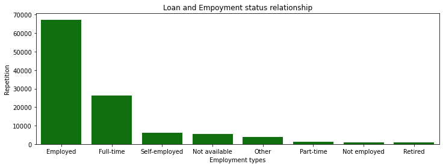

```python
#We will use countplot to show the relationship
plt.figure(figsize=[12, 4]);
sns.countplot(data = prosper_data, x = 'EmploymentStatus', color = 'green');
plt.title('Loan and Empoyment status relationship');
plt.ylabel('Repetition');
plt.xlabel('Employment types');
plt.xticks(rotation=0);
```

As we can see unemployed + retired have low potential to get loan.

### Income Range:

For borrower does Prosper check the income for them?

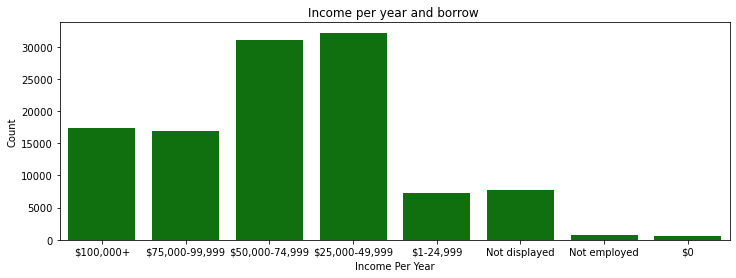

```python
#showing the income and borrowing
plt.figure(figsize=[12, 4]);
sns.countplot(data = prosper_data, x = 'IncomeRange', color = 'green');
plt.title('Income per year and borrow ');
plt.ylabel('Count');
plt.xlabel('Income Per Year');
plt.xticks(rotation=0);
```

As we can see for 0$ and unemployed almost cannot borrow.

### Loan Status:

If someone has a loan from prosper what is the status of his loan ?

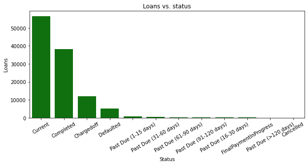

```python
#Showing the status of loans
plt.figure(figsize=[10, 4]);
sns.countplot(data = prosper_data, x = 'LoanStatus', color = 'green');
plt.title('Loans vs. status');
plt.ylabel('Loans');
plt.xlabel('Status');
plt.xticks(rotation=30);
```

As we can see from the chart almost 40,000 loans are completed and the current are not completed yet.

### Prosper Score:

For borrowers what is the relationship between them and Prosper score?

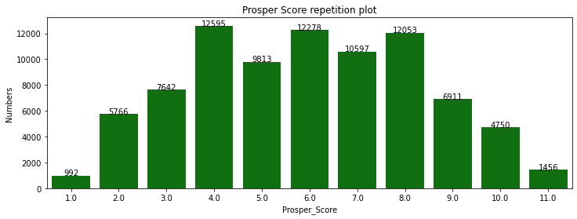

```python
#Prosper score and
plt.figure(figsize=[12, 4]);
sns.countplot(data = prosper_data, x = 'ProsperScore', color = 'green');
plt.title('Prosper Score repetition plot');
plt.xlabel('Prosper_Score');
plt.ylabel('Numbers');
lg, elements = plt.xticks()
cat_counts = prosper_data['ProsperScore'].value_counts()

for i, ele in zip(lg, elements):
    count = cat_counts[float(ele.get_text())]
    pct_string = '{}'.format(count)
    plt.text(i, count, pct_string, ha = 'center', color = 'black')
```

We can see the score for people is between 4 to 8 and at 4 we can see the highest

### Borrower APR:

If some people have a loan what is the Annual Percentage Rate?

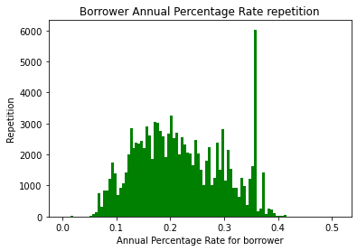

```python
#Distribution of Borrower Annual Percentage Rate repetition
binss = np.arange(0,prosper_data['BorrowerAPR'].value_counts().index.max(),0.005)
plt.hist(data = prosper_data, x = 'BorrowerAPR', bins = binss, color = 'green');

plt.title('Borrower Annual Percentage Rate repetition');
plt.xlabel('Annual Percentage Rate for borrower');
plt.ylabel('Repetition');
```

We can notice that the graph almost skweed to the right, the graph tell us the highest value is at 0.36

### Monthly Loan Payment

In this section we are focusing on the payments for the borrower

For borrower what is the payment that they made?

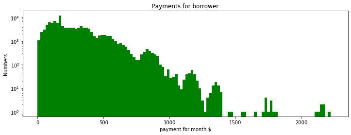

```python
#Monthly payments that borroweers made
#the below funstion to create log with the base 10
def log_trans(x, inverse = False):
    if not inverse:
        return np.log10(x)
    else:
        return np.power(10, x)
plt.figure(figsize=[12, 4]);
graph_bin = np.arange(0,prosper_data['MonthlyLoanPayment'].value_counts().index.max(),20)
plt.hist(data = prosper_data, x = 'MonthlyLoanPayment', bins = graph_bin, color = 'green');
plt.title('Payments for borrower');
plt.xlabel('payment for month $');
plt.ylabel('Numbers');
plt.yscale('log', nonposy='clip');
```

We can notice that the payment less than 2000 and rarely above 2000, we can also see that the graph is skewed to the right

### Profession

compute the Proffession of borrowers?

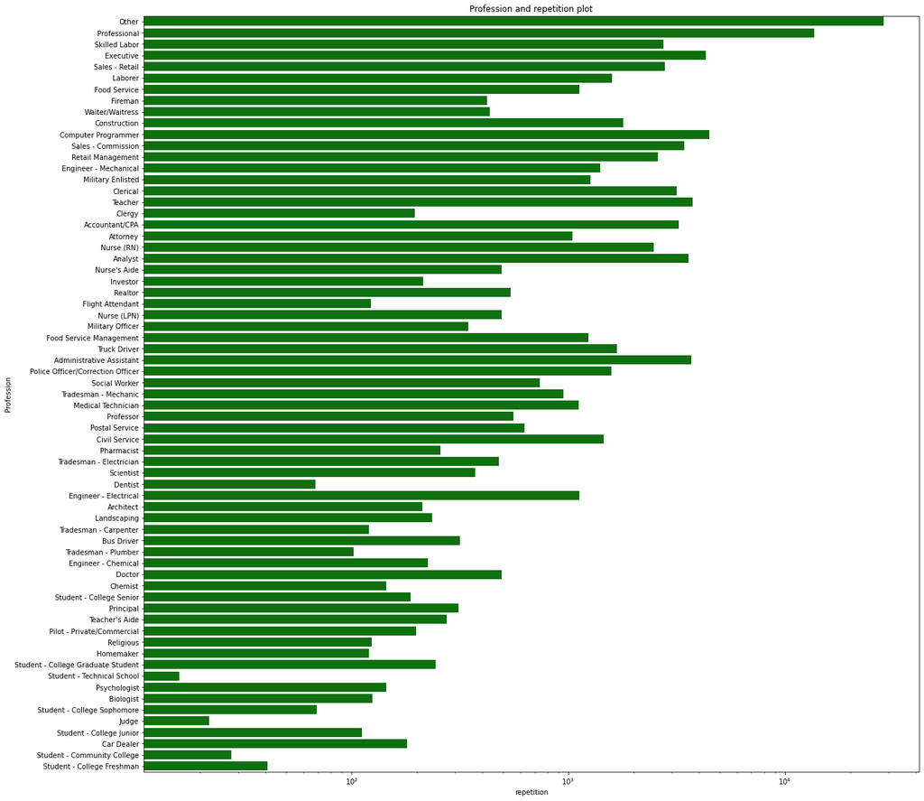

```python
#Highest borrowers from which profission
plt.figure(figsize=[20,20]);
sns.countplot(data = prosper_data, y = 'Occupation', color = "green");
plt.title('Profession and repetition plot');
plt.ylabel('Profession');
plt.xlabel('repetition');
plt.xscale('log');
```

#### Showing highest professions

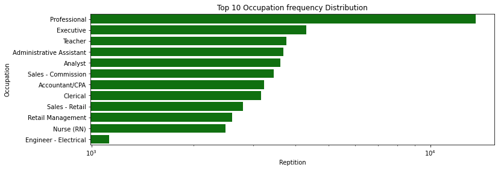

```python
#Summerize the highest professions
plt.figure(figsize=[12, 4]);
top_ten_occupation = ['Professional','Executive','Engineer - Electrical','Teacher','Administrative Assistant','Analyst','Sales - Commission','Accountant/CPA','Clerical','Sales - Retail','Nurse (RN)','Retail Management']
occupation_sub = prosper_data.loc[prosper_data['Occupation'].isin(top_ten_occupation)]
sns.countplot(data = occupation_sub, y = 'Occupation', order = occupation_sub['Occupation'].value_counts().index, color = 'green');
plt.title('Top 10 Occupation frequency Distribution');
plt.ylabel('Occupation');
plt.xlabel('Reptition');
plt.xscale('log');
```

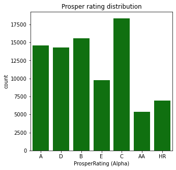

```python
fig, ax = plt.subplots(figsize = [5,5])
#default_color = sns.color_palette()
sns.countplot(data = prosper_data, x = 'ProsperRating (Alpha)', color = 'green')
plt.title('Prosper rating distribution');
```

This is the distribution of the ratings and as we can notice the rating c gets the highest number of loans, then we have the rating B.

### Loan amount

showing the loan amount of the dataset

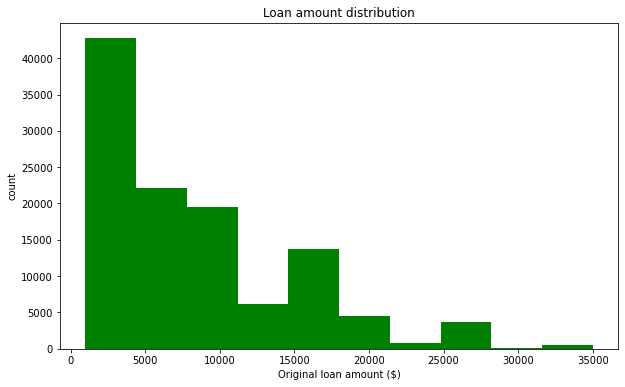

```python
plt.figure(figsize=[10, 6])
plt.hist(prosper_data['LoanOriginalAmount'], color = 'green');
plt.xlabel('Original loan amount ($)');
plt.ylabel('count')
plt.title('Loan amount distribution')
```

This is the distribution of the loan amount, we can see the highest is before 5000 loan.

### Term Distribution

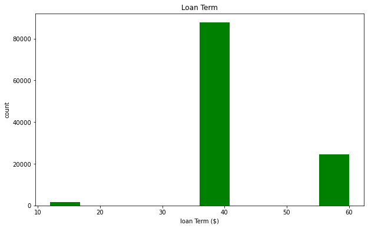

```python
plt.figure(figsize=[10, 6])
plt.hist(prosper_data['Term'], color = 'green');
plt.xlabel('loan Term ($)');
plt.ylabel('count')
plt.title('Loan Term')
```

The distribution of the loan term, it's consist of 12, 36,60, as we can see 36 gets the highest with for people who got loans.

### Estimated Return distribution

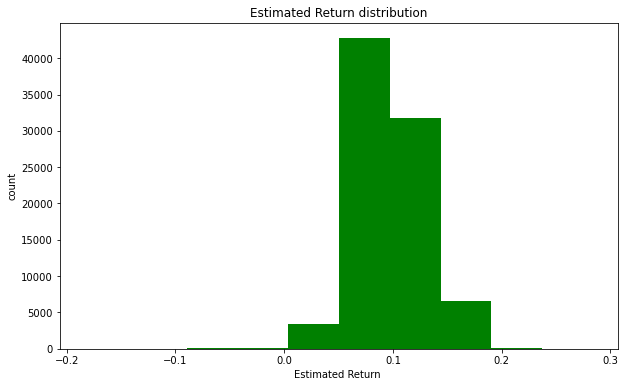

```python
plt.figure(figsize=[10, 6])
plt.hist(prosper_data['EstimatedReturn'], color = 'green');
plt.xlabel('Estimated Return ');
plt.ylabel('count')
plt.title('Estimated Return distribution')
```

We can see from the plot the distribtuion of the "EstimatedReturn", the values are bertween 0.0 to 0.2 and the hieghest values gets 40000

### Of the features investigated, were there any unusual distributions? Did you perform any operations on the data to tidy, adjust, or change the form of the data? If so, why did you do this?

We can see the payments per months are almost less than 1500 and it is's right skewed. We saw and discuss the loan term and how it effect on another featurs. We don't need to do transformations or changing the data.

## Bivariate Exploration

### Quantitative vs. Quantitative

Now we will compare two variables that we are interested

```python
# simplified actual return formula
prosper_data['Actual_Returns'] = prosper_data.LP_CustomerPayments - prosper_data.LoanOriginalAmount - (prosper_data.LP_ServiceFees + prosper_data.LP_CollectionFees + prosper_data.LP_NetPrincipalLoss)
prosper_data['Actual_Returns'] = (prosper_data.Actual_Returns / prosper_data.LoanOriginalAmount) + 1
```

```python
# numeric and categorical variables
kp1 = ['DebtToIncomeRatio', 'Actual_Returns', 'EstimatedReturn']
kp2 = ['IncomeRange', 'ProsperRatingCombined']
```

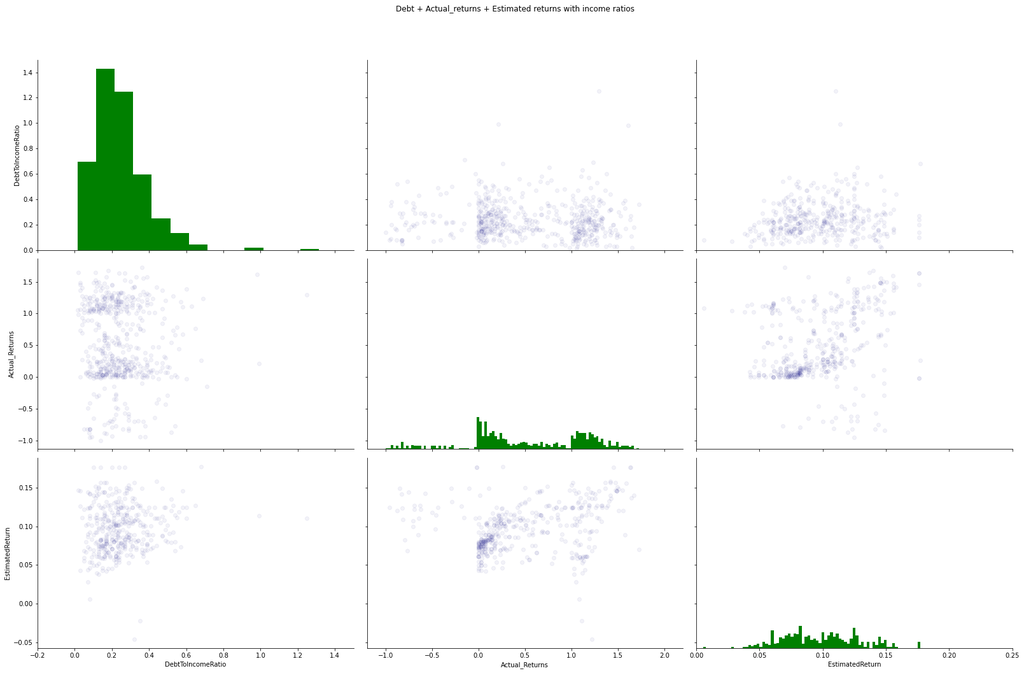

```python
data1 = np.random.choice(prosper_data.shape[0], int(prosper_data.shape[0]*.005), replace = False)
dd = prosper_data.loc[data1,:]
kp = sns.PairGrid(data = dd, vars = kp1, size = 5, aspect = 1.5)
kp = kp.map_diag(plt.hist, bins = 100, color = 'green')
kp.map_offdiag(plt.scatter, alpha = 1/20, color = 'navy')

kp.axes[0,0].set_ylim(0,1.5)
kp.axes[0,0].set_xlim(-.2,1.5)
kp.axes[0,1].set_xlim(-1.2,2.2)
kp.axes[0,2].set_xlim(0,.25)

kp.fig.suptitle('Debt + Actual_returns + Estimated returns with income ratios')
kp.fig.subplots_adjust(top = .90);
```

We can see from the plots that there is no relationship between the estimated return and the actual return.

### Quantitative vs. Qualitative

Now we will check the relationship between the expected returns with the income and credit rating

```python
# change the NC to HR
prosper_data['CreditGrade'].replace(['NC', 'HR'], 'E', inplace = True)

# change NA to be empty
prosper_data['ProsperRating (Alpha)'].fillna("", inplace = True)
prosper_data['CreditGrade'].fillna("", inplace = True)
prosper_data['Org_rating'] = prosper_data['ProsperRating (Alpha)'] + prosper_data['CreditGrade']
# delete the rows with empty credit ratings
prosper_data = prosper_data.query(' Org_rating != ""')

# check values
prosper_data['Org_rating'].value_counts()
```

```
C     23994
B     19970
D     19427
A     17866
E     16733
AA     8881
HR     6935
Name: Org_rating, dtype: int64
```

```python
prosper_data['CreditGrade'].replace(['NC', 'AA'], 'E', inplace = True)
prosper_data['CreditGrade'].fillna("", inplace = True)

prosper_data = prosper_data.query('Org_rating != ""')

prosper_data['Org_rating'].value_counts()
```

```
C     23994
B     19970
D     19427
A     17866
E     16733
AA     8881
HR     6935
Name: Org_rating, dtype: int64
```

```python
rating = ['AA', 'A', 'B', 'C', 'D', 'E']
order = pd.api.types.CategoricalDtype(ordered = True, categories = rating)
prosper_data['Org_rating'] = prosper_data['Org_rating'].astype(order)
```

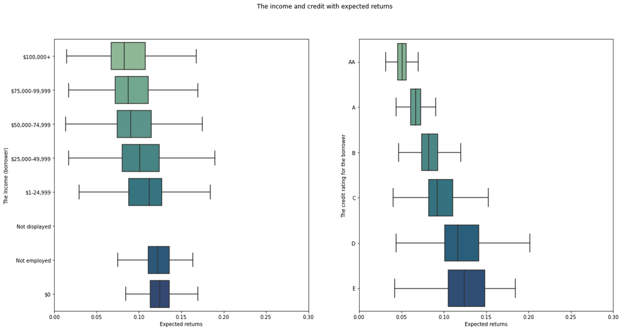

```python
plt.figure(figsize = [20, 10])

plt.subplot(1, 2, 1)
#base_color = sns.color_palette()[0]
sns.boxplot(data = prosper_data, y = 'IncomeRange', x = 'EstimatedReturn', palette = "crest", showfliers = False)
plt.xlim(0,.3)
plt.ylabel('The Income (borrower)')
plt.xlabel('Expected returns')

plt.subplot(1, 2, 2)
#base_color = sns.color_palette()[0]
sns.boxplot(data = prosper_data, y = 'Org_rating', x = 'EstimatedReturn', palette = "crest", showfliers = False)
plt.xlim(0,.3)
plt.ylabel('The credit rating for the borrower')
plt.xlabel('Expected returns')

plt.suptitle('The income and credit with expected returns');
```

As we can notice from the graphs the relationship between the income and expected return is negative relationship

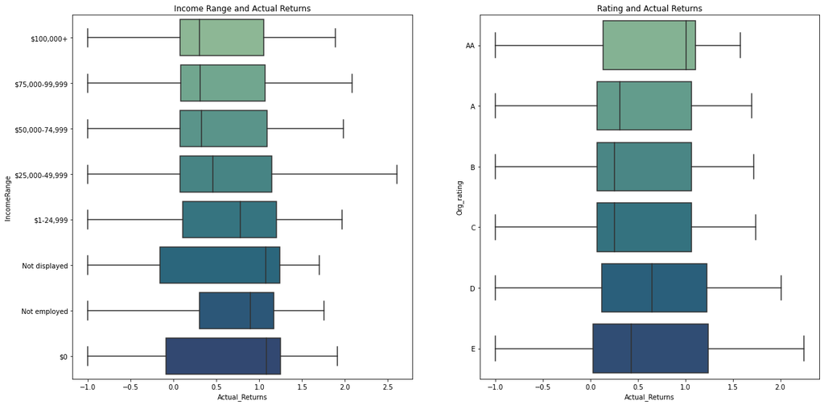

```python
plt.figure(figsize = [20, 10])

plt.subplot(1, 2, 1)
sns.boxplot(data = prosper_data, y = 'IncomeRange', x = 'Actual_Returns', palette = "crest", showfliers = False).set_title('Income Range and Actual Returns')

plt.subplot(1, 2, 2)
sns.boxplot(data = prosper_data, y = 'Org_rating', x = 'Actual_Returns', palette = "crest", showfliers = False).set_title('Rating and Actual Returns');
```

### Qualitative vs. Qualitiative

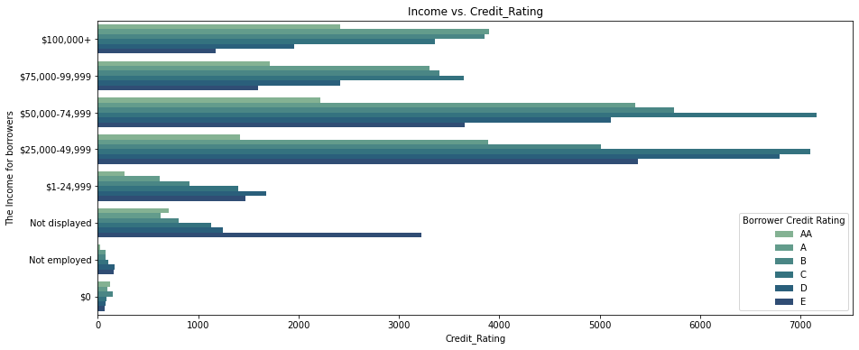

```python
# clustered bar chart
plt.figure(figsize = [15,6])

ax = sns.countplot(data = prosper_data, y = 'IncomeRange', hue = 'Org_rating',
                   palette = 'crest')

ax.legend(title = 'Borrower Credit Rating')
plt.title('Income vs. Credit_Rating')
plt.xlabel('Credit_Rating');
plt.ylabel('The Income for borrowers');
```

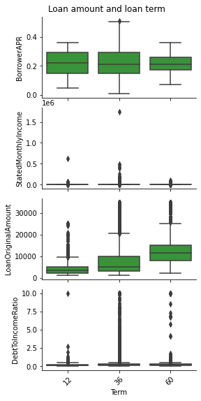

```python
def boxgrid(x, y, **kwargs):
    """ Quick hack for creating box plots with seaborn's PairGrid. """
    default_color = sns.color_palette()[2]
    sns.boxplot(x, y, color = default_color)

plt.figure(figsize = [9, 9])
g = sns.PairGrid(data = prosper_data, y_vars = ['BorrowerAPR', 'StatedMonthlyIncome', 'LoanOriginalAmount','DebtToIncomeRatio'],
                x_vars = ['Term'], height = 2, aspect = 2)
g.fig.subplots_adjust(top=0.95)
g.map(boxgrid);
plt.xticks(rotation=45);
plt.suptitle('Loan amount and loan term')
```

### How did the feature(s) of interest vary with other features in the dataset?

We can notice that the relationship between the borrowing and getting loans has a relationship with the status of the employee for unemployed has low opertunities for borrowing. We can notice that the loan term effect positively on the loan amount.

### Did you observe any interesting relationships between the other features (not the main feature(s) of interest)?

Yes, I noticed the boxplots the relationship between the income and expected return has negative relationship

### Multivariate Exploration

What we are focusing here in this sections is the corrolation between the rating for Prosper + Term and the borrower Annual Percentage Rate (APR)

```python
prosper_data = prosper_data.rename(columns={'LoanOriginalAmount': 'LoanOriginalAmount(USD)'})
```

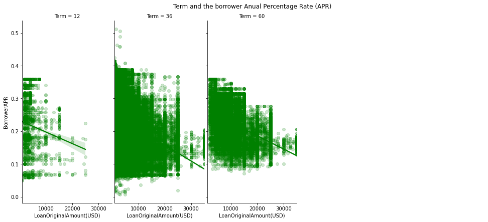

```python
#We will use jitter to add displacement to the visual and we choose 0.08
#We used the parameter alpha to prvide transparency with 0.2
kk=sns.FacetGrid(data= prosper_data, aspect=1.3, height=10, col='Term', col_wrap=5)
kk.map(sns.regplot, 'LoanOriginalAmount(USD)', 'BorrowerAPR', x_jitter=0.08, scatter_kws={'alpha':0.2}, color = 'green')

kk.add_legend();
kk.fig.subplots_adjust(top=0.9)
kk.fig.suptitle('Term and the borrower Anual Percentage Rate (APR)')
# We need to get bigger visual to make it clear
kk.fig.set_figwidth(13)
kk.fig.set_figheight(6)
```

We can notice that tirm has little effect on the loan amount with the ARP

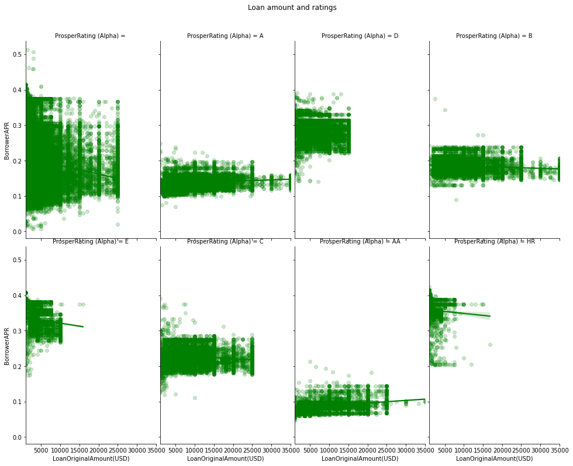

```python
kk=sns.FacetGrid(data=prosper_data, aspect=1.3, height=10, col='ProsperRating (Alpha)', col_wrap=4)
kk.map(sns.regplot, 'LoanOriginalAmount(USD)', 'BorrowerAPR', x_jitter=0.03, scatter_kws={'alpha':0.2}, color = 'green');
kk.add_legend()
kk.fig.subplots_adjust(top=0.9)
kk.fig.suptitle('Loan amount and ratings')
kk.fig.set_figwidth(13)
kk.fig.set_figheight(11)
```

We can notice that the loan amount and ratings has positive relationship. Since AA ratings take extra loans the relationsship between borrower's ARP with the amount of loan becomes positive.

```python
order = ['HR','E','D','C','B','A','AA']
ov = pd.api.types.CategoricalDtype(ordered = True,
                                    categories = order)
prosper_data['ProsperRating (Alpha)'] = prosper_data['ProsperRating (Alpha)'].astype(ov)
```

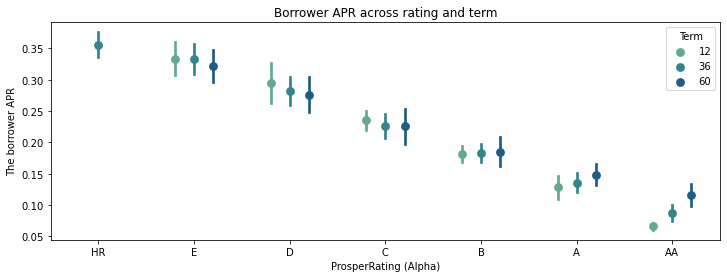

```python
#We will use pointplot to show point estimates

fig = plt.figure(figsize = [12,4])
ax = sns.pointplot(data = prosper_data, x = 'ProsperRating (Alpha)', y = 'BorrowerAPR', hue = 'Term',
           palette = 'crest', linestyles = '', dodge = 0.4, ci='sd')
plt.title('Borrower APR across rating and term')
plt.ylabel('The borrower APR')
ax.set_yticklabels([],minor = True);
```

```python
array = ['Employed','Self-employed','Full-time','Part-time','Retired','Other','Not employed', 'Not available']
order = pd.api.types.CategoricalDtype(ordered = True,
                                    categories = array)
prosper_data['EmploymentStatus'] = prosper_data['EmploymentStatus'].astype(order)
```

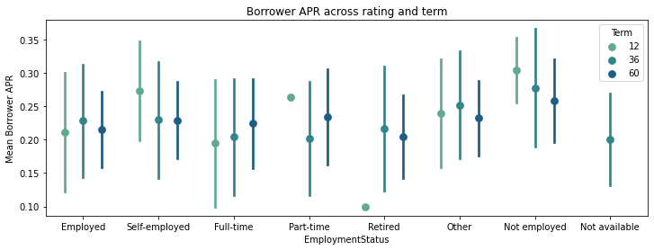

```python
fig = plt.figure(figsize = [12,4])
ax = sns.pointplot(data = prosper_data, x = 'EmploymentStatus', y = 'BorrowerAPR', hue = 'Term',
           palette = 'crest', linestyles = '', dodge = 0.5, ci='sd')
plt.title('Borrower APR across rating and term')
plt.ylabel('Mean Borrower APR')
ax.set_yticklabels([],minor = True);
plt.xticks(rotation = 0);
```

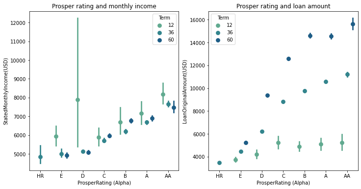

```python
#Now we will plot the relationship between prosper rating and loan and monthly income
prosper_data = prosper_data.rename(columns={'StatedMonthlyIncome': 'StatedMonthlyIncome(USD)'})
fig, ax = plt.subplots(ncols=2, figsize=[12,6])
sns.pointplot(data = prosper_data, x = 'ProsperRating (Alpha)', y = 'StatedMonthlyIncome(USD)', hue = 'Term',
           palette = 'crest', linestyles = '', dodge = 0.5, ax=ax[0]).set_title('Prosper rating and monthly income')

sns.pointplot(data = prosper_data, x = 'ProsperRating (Alpha)', y = 'LoanOriginalAmount(USD)', hue = 'Term',
           palette = 'crest', linestyles = '', dodge = 0.5, ax=ax[1]).set_title('Prosper rating and loan amount');
```

### Were there features that strengthened each other in terms of looking at your feature(s) of interest?

By checking the effect of prosper rating (Alpha) on borrower APR vs. loan amount the relationship become positive for the ratings. After that checked the rating and term how they effect on loan amount and what I noticed when the loan amount increase in the three terms for increasing the rates, aslo the tall of the loan is larger

```python
!jupyter nbconvert loan_data_exploration.ipynb --to slides --post serve  --no-input --no-prompt
```

```
[NbConvertApp] Converting notebook loan_data_exploration.ipynb to slides
[NbConvertApp] Writing 1010014 bytes to loan_data_exploration.slides.html
[NbConvertApp] Redirecting reveal.js requests to https://cdnjs.cloudflare.com/ajax/libs/reveal.js/3.5.0
Serving your slides at http://127.0.0.1:8000/loan_data_exploration.slides.html
Use Control-C to stop this server
^C

Interrupted
```